# MTCARS Classification Analysis

[figure not shown]

### Problem Statement

To implement classification models using the mtcars dataset.

In this project, we aim to implement classification models using the mtcars dataset in R. While the mtcars dataset is traditionally used for regression due to its continuous variables, we will transform it into a classification problem by converting one of the continuous variables into a categorical target variable. This approach enables us to explore classification techniques within the context of a well-known dataset.

##### Step-by-Step Implementation

1. **Prepare the Data**: We’ll first convert the `mpg` variable into a binary classification label: High or Low MPG.
2. **Train Classification Models**: We’ll then apply several classification algorithms like Logistic Regression, Decision Trees, Random Forest, and k-Nearest Neighbors.

[figure not shown]

### Data Preparation

Convert the `mpg` variable into a binary classification label.

##### Display the first six rows of the dataset

```
                   mpg cyl disp  hp drat    wt  qsec vs am gear carb
Mazda RX4         21.0   6  160 110 3.90 2.620 16.46  0  1    4    4
Mazda RX4 Wag     21.0   6  160 110 3.90 2.875 17.02  0  1    4    4
Datsun 710        22.8   4  108  93 3.85 2.320 18.61  1  1    4    1
Hornet 4 Drive    21.4   6  258 110 3.08 3.215 19.44  1  0    3    1
Hornet Sportabout 18.7   8  360 175 3.15 3.440 17.02  0  0    3    2
Valiant           18.1   6  225 105 2.76 3.460 20.22  1  0    3    1
```

##### Create new attribute by converting ‘mpg’ into a binary classification target: High MPG (>20) or Low MPG (<=20)

```r
mtcars$mpg_class <- ifelse(mtcars$mpg > 20, "High", "Low")
```

##### Check the structure of the dataset

```
'data.frame':   32 obs. of  12 variables:
 $ mpg      : num  21 21 22.8 21.4 18.7 18.1 14.3 24.4 22.8 19.2 ...
 $ cyl      : num  6 6 4 6 8 6 8 4 4 6 ...
 $ disp     : num  160 160 108 258 360 ...
 $ hp       : num  110 110 93 110 175 105 245 62 95 123 ...
 $ drat     : num  3.9 3.9 3.85 3.08 3.15 2.76 3.21 3.69 3.92 3.92 ...
 $ wt       : num  2.62 2.88 2.32 3.21 3.44 ...
 $ qsec     : num  16.5 17 18.6 19.4 17 ...
 $ vs       : num  0 0 1 1 0 1 0 1 1 1 ...
 $ am       : num  1 1 1 0 0 0 0 0 0 0 ...
 $ gear     : num  4 4 4 3 3 3 3 4 4 4 ...
 $ carb     : num  4 4 1 1 2 1 4 2 2 4 ...
 $ mpg_class: chr  "High" "High" "High" "High" ...
```

##### Convert the categorical variable to factors

```r
mtcars$mpg_class <- as.factor(mtcars$mpg_class)
```

##### Display the first six rows of the dataset

```
                   mpg cyl disp  hp drat    wt  qsec vs am gear carb mpg_class
Mazda RX4         21.0   6  160 110 3.90 2.620 16.46  0  1    4    4      High
Mazda RX4 Wag     21.0   6  160 110 3.90 2.875 17.02  0  1    4    4      High
Datsun 710        22.8   4  108  93 3.85 2.320 18.61  1  1    4    1      High
Hornet 4 Drive    21.4   6  258 110 3.08 3.215 19.44  1  0    3    1      High
Hornet Sportabout 18.7   8  360 175 3.15 3.440 17.02  0  0    3    2       Low
Valiant           18.1   6  225 105 2.76 3.460 20.22  1  0    3    1       Low
```

##### Display the summary of the dataset

```
      mpg             cyl             disp             hp
 Min.   :10.40   Min.   :4.000   Min.   : 71.1   Min.   : 52.0
 1st Qu.:15.43   1st Qu.:4.000   1st Qu.:120.8   1st Qu.: 96.5
 Median :19.20   Median :6.000   Median :196.3   Median :123.0
 Mean   :20.09   Mean   :6.188   Mean   :230.7   Mean   :146.7
 3rd Qu.:22.80   3rd Qu.:8.000   3rd Qu.:326.0   3rd Qu.:180.0
 Max.   :33.90   Max.   :8.000   Max.   :472.0   Max.   :335.0
      drat             wt             qsec             vs
 Min.   :2.760   Min.   :1.513   Min.   :14.50   Min.   :0.0000
 1st Qu.:3.080   1st Qu.:2.581   1st Qu.:16.89   1st Qu.:0.0000
 Median :3.695   Median :3.325   Median :17.71   Median :0.0000
 Mean   :3.597   Mean   :3.217   Mean   :17.85   Mean   :0.4375
 3rd Qu.:3.920   3rd Qu.:3.610   3rd Qu.:18.90   3rd Qu.:1.0000
 Max.   :4.930   Max.   :5.424   Max.   :22.90   Max.   :1.0000
       am              gear            carb       mpg_class
 Min.   :0.0000   Min.   :3.000   Min.   :1.000   High:14
 1st Qu.:0.0000   1st Qu.:3.000   1st Qu.:2.000   Low :18
 Median :0.0000   Median :4.000   Median :2.000
 Mean   :0.4062   Mean   :3.688   Mean   :2.812
 3rd Qu.:1.0000   3rd Qu.:4.000   3rd Qu.:4.000
 Max.   :1.0000   Max.   :5.000   Max.   :8.000
```

The `mtcars` dataset provides various automobile attributes, and the statistical summary offers insights into their distribution and central tendencies.

The **miles per gallon (mpg)** ranges from 10.4 to 33.9, with a mean of approximately 20.1. This indicates that most cars in the dataset are moderately fuel efficient, with half of them getting between 15.43 and 22.8 mpg. The **number of cylinders (cyl)** varies from 4 to 8, with most cars likely having 4, 6, or 8 cylinders, which are common configurations in standard and performance vehicles.

**Engine displacement (disp)** ranges from 71.1 to 472.0 cubic inches, with a mean of 230.7. This wide range reflects a diverse mix of small to large engines. Similarly, **horsepower (hp)** spans from 52 to 335, with an average of 146.7, indicating that while some cars are relatively low-powered, others offer high-performance capabilities.

The **rear axle ratio (drat)**, which impacts engine revolutions and fuel efficiency, ranges from 2.76 to 4.93, averaging around 3.6. The **weight of the cars (wt)** varies from 1,513 to 5,424 pounds (in 1,000 lbs units), with a mean weight of 3,217 lbs, showing a substantial spread in vehicle mass. The **quarter-mile time (qsec)** ranges from 14.5 to 22.9 seconds, with a mean of 17.85 seconds, providing insight into acceleration performance.

Binary variables in the dataset include **engine shape (vs)**, where 0 denotes a V-shaped engine and 1 a straight engine. The average value of 0.44 indicates a slightly higher number of V-shaped engines. **Transmission type (am)** is also binary, with 0 representing automatic and 1 manual; with a mean of 0.406, about 40% of the cars are manual transmission.

The **number of forward gears (gear)** ranges from 3 to 5, with most vehicles having either 3 or 4 gears. The **number of carburetors (carb)** shows considerable variation, from 1 to 8, with a mean of 2.81, reflecting a mix of simple and more complex engine setups.

Finally, the **mpg_class** is a derived categorical variable that classifies cars into “High” or “Low” efficiency based on a threshold, likely 20 mpg. This classification simplifies fuel efficiency comparisons across the dataset.

### Logistic Regression

Logistic Regression can be used for binary classification tasks, where the goal is to predict the probability of the target variable being one of the classes.

#### Fit a logistic regression model

```r
logit_model <- glm(mpg_class ~ wt + hp + qsec + drat + cyl, data = mtcars, family = "binomial")
```

#### Summary of the model

```
Call:
glm(formula = mpg_class ~ wt + hp + qsec + drat + cyl, family = "binomial",
    data = mtcars)

Coefficients:
              Estimate Std. Error z value Pr(>|z|)
(Intercept) -2.246e+01  1.115e+06   0.000    1.000
wt           2.115e+02  1.388e+05   0.002    0.999
hp           1.129e+00  2.132e+03   0.001    1.000
qsec        -2.137e+01  4.784e+04   0.000    1.000
drat        -3.637e+01  7.162e+04  -0.001    1.000
cyl         -4.579e+01  4.579e+04  -0.001    0.999

(Dispersion parameter for binomial family taken to be 1)

    Null deviance: 4.3860e+01  on 31  degrees of freedom
Residual deviance: 5.6447e-09  on 26  degrees of freedom
AIC: 12

Number of Fisher Scoring iterations: 25
```

#### Make predictions on the dataset

```r
pred_logit <- predict(logit_model, type = "response")
pred_logit_class <- ifelse(pred_logit > 0.5, "High", "Low")
```

#### Confusion matrix to evaluate the model

```
pred_logit_class High Low
            High    0  18
            Low    14   0
```

### Decision Tree

A decision tree is a non-linear model that recursively splits the data based on feature values to predict the target class.

##### Fit a decision tree model

```r
tree_model <- rpart(mpg_class ~ wt + hp + qsec + drat + cyl,
                    data = mtcars,
                    method = "class")
```

##### Plot the decision tree

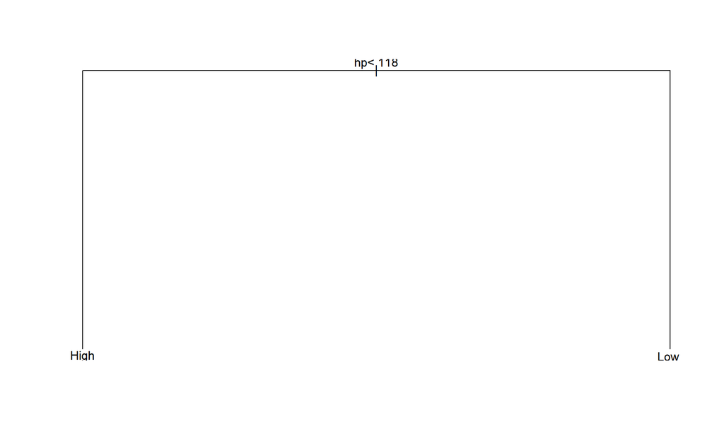

##### Make predictions

```r
pred_tree <- predict(tree_model, type = "class")
```

##### Confusion matrix to evaluate the model

```
pred_tree High Low
     High   14   1
     Low     0  17
```

### Random Forest

Random Forest is an ensemble method that uses multiple decision trees to improve classification accuracy and reduce overfitting.

#### Fit a random forest model

```r
rf_model <- randomForest(mpg_class ~ wt + hp + qsec + drat + cyl,
                         data = mtcars)
```

#### Print the model summary

```
Call:
 randomForest(formula = mpg_class ~ wt + hp + qsec + drat + cyl,      data = mtcars)
               Type of random forest: classification
                     Number of trees: 500
No. of variables tried at each split: 2

        OOB estimate of  error rate: 6.25%
Confusion matrix:
     High Low class.error
High   13   1  0.07142857
Low     1  17  0.05555556
```

#### Make predictions

```r
pred_rf <- predict(rf_model)
```

#### Confusion matrix to evaluate the model

```
pred_rf High Low
   High   13   1
   Low     1  17
```

### k-Nearest Neighbor (k-NN)

k-NN is a simple algorithm that assigns the class based on the majority class of the k-nearest neighbors.

#### Prepare training data and labels

```r
X <- mtcars[, c("wt", "hp", "qsec", "drat", "cyl")]
y <- mtcars$mpg_class
```

#### Fit the k-NN model with k = 3

```r
knn_model <- knn(X, X, y, k = 3)
```

#### Confusion matrix to evaluate the model

```
knn_model High Low
     High   14   1
     Low     0  17
```

#### Confusion matrix results explanation

In terms of performance, the overall **accuracy** of the model is high:
$$(TP + TN) / Total = (14 + 17) / 32 =
96.88%$$
.
This means that the model correctly predicted the mpg class for approximately 97% of the vehicles.

### Model Evaluation

For evaluating the classification models, we can use common metrics such as:

- **Accuracy**: The proportion of correct predictions.
- **Confusion Matrix**: A table showing true positives, false positives, true negatives, and false negatives.

Accuracy for Logistic Regression

Accuracy for Decision Tree

Accuracy for Random Forest

Accuracy for k-NN

[output not shown]

### Model Summary

We have implemented four classification models on the `mtcars` dataset:

1. **Logistic Regression**
2. **Decision Tree**
3. **Random Forest**
4. **k-Nearest Neighbors (k-NN)**

These models can be evaluated by their confusion matrices and accuracy scores. Depending on the results, you can choose the model that performs best in terms of classification accuracy or other evaluation metrics (e.g., precision, recall, F1-score).

#### Additional Considerations

- **Feature Engineering**: You may need to transform or scale the data to improve model performance, especially for distance-based algorithms like k-NN.
- **Hyperparameter Tuning**: For models like Random Forest and k-NN, it’s important to tune hyperparameters (e.g., the number of trees for Random Forest, or the value of k for k-NN) to optimize performance.